# Exploratory Data Analysis Report

2022-10-11

## Exploratory Data analysis (EDA)

Analyzing the data sets to summarize their main characteristics of variables, often with visual graphs, without using a statistical model.

### 1. Overview of the data

Understanding the dimensions of the dataset, variable names, overall missing summary and data types of each variables

```r
# Overview of the data
ExpData(data=data,type=1)
# Structure of the data
ExpData(data=data,type=2)
```

**Overview of the data**

| Descriptions | Value |
| --- | --- |
| Sample size (nrow) | 70000 |
| No. of variables (ncol) | 12 |
| No. of numeric/interger variables | 5 |
| No. of factor variables | 7 |
| No. of text variables | 0 |
| No. of logical variables | 0 |
| No. of identifier variables | 0 |
| No. of date variables | 0 |
| No. of zero variance variables (uniform) | 0 |
| %. of variables having complete cases | 100% (12) |

[output cut: 3 more lines]

**Structure of the data**

| Index | Variable_Name | Variable_Type | Sample_n | Missing_Count | Per_of_Missing | No_of_distinct_values |
| --- | --- | --- | --- | --- | --- | --- |
| 1 | age | numeric | 70000 | 0 | 0 | 28 |
| 2 | gender | factor | 70000 | 0 | 0 | 2 |
| 3 | height | integer | 70000 | 0 | 0 | 109 |
| 4 | weight | numeric | 70000 | 0 | 0 | 287 |
| 5 | ap_hi | integer | 70000 | 0 | 0 | 153 |
| 6 | ap_lo | integer | 70000 | 0 | 0 | 157 |
| 7 | cholesterol | factor | 70000 | 0 | 0 | 3 |
| 8 | gluc | factor | 70000 | 0 | 0 | 3 |
| 9 | smoke | factor | 70000 | 0 | 0 | 2 |
| 10 | alco | factor | 70000 | 0 | 0 | 2 |

[output cut: 2 more lines]

**Target variable**

Summary of categorical dependent variable

```
##   cardio Frequency Descriptions
## 1      0     35021       cardio
## 2      1     34979       cardio
```

### 2. Summary of numerical variables

Summary of all numerical variables

Summary statistics when dependent variable is categorical **cardio**. Summary statistics will be splitted into category level

```r
ExpNumStat(data,by="GA",gp=Target,Qnt=seq(0,1,0.1),MesofShape=2,Outlier=TRUE,round=2)
```

| Vname | Group | TN | nNeg | nZero | nPos | NegInf | PosInf | NA_Value | Per_of_Missing | sum | min | max | mean | median | SD | CV | IQR | Skewness | Kurtosis | 0% | 10% | 20% | 30% | 40% | 50% | 60% | 70% | 80% | 90% | … |
| --- | --- | --- | --- | --- | --- | --- | --- | --- | --- | --- | --- | --- | --- | --- | --- | --- | --- | --- | --- | --- | --- | --- | --- | --- | --- | --- | --- | --- | --- | --- |
| age | cardio:All | 70000 | 0 | 0 | 70000 | 0 | 0 | 0 | 0 | 3733708 | 30 | 65 | 53.34 | 54 | 6.77 | 0.13 | 10 | -0.31 | -0.82 | 30 | 43 | 47 | 50 | 52 | 54 | 56 | 58 | 60 | 62 | … |
| age | cardio:0 | 35021 | 0 | 0 | 35021 | 0 | 0 | 0 | 0 | 1811679 | 30 | 65 | 51.73 | 52 | 6.79 | 0.13 | 11 | -0.12 | -0.94 | 30 | 42 | 44 | 48 | 50 | 52 | 54 | 56 | 58 | 60 | … |
| age | cardio:1 | 34979 | 0 | 0 | 34979 | 0 | 0 | 0 | 0 | 1922029 | 39 | 65 | 54.95 | 56 | 6.35 | 0.12 | 10 | -0.49 | -0.56 | 39 | 46 | 50 | 52 | 54 | 56 | 58 | 60 | 61 | 63 | … |
| ap_hi | cardio:All | 70000 | 7 | 0 | 69993 | 0 | 0 | 0 | 0 | 9017210 | -150 | 16020 | 128.82 | 120 | 154.01 | 1.20 | 20 | 85.29 | 7579.53 | -150 | 110 | 120 | 120 | 120 | 120 | 130 | 130 | 140 | 150 | … |
| ap_hi | cardio:0 | 35021 | 4 | 0 | 35017 | 0 | 0 | 0 | 0 | 4217670 | -120 | 14020 | 120.43 | 120 | 103.55 | 0.86 | 10 | 124.35 | 16124.78 | -120 | 110 | 110 | 120 | 120 | 120 | 120 | 120 | 125 | 130 | … |
| ap_hi | cardio:1 | 34979 | 3 | 0 | 34976 | 0 | 0 | 0 | 0 | 4799540 | -150 | 16020 | 137.21 | 130 | 191.29 | 1.39 | 20 | 69.24 | 4977.95 | -150 | 120 | 120 | 120 | 130 | 130 | 140 | 140 | 150 | 160 | … |
| ap_lo | cardio:All | 70000 | 1 | 21 | 69978 | 0 | 0 | 0 | 0 | 6764129 | -70 | 11000 | 96.63 | 80 | 188.47 | 1.95 | 10 | 32.11 | 1425.81 | -70 | 70 | 79 | 80 | 80 | 80 | 80 | 82 | 90 | 90 | … |
| ap_lo | cardio:0 | 35021 | 0 | 15 | 35006 | 0 | 0 | 0 | 0 | 2950581 | 0 | 9800 | 84.25 | 80 | 152.69 | 1.81 | 10 | 45.81 | 2408.15 | 0 | 70 | 70 | 80 | 80 | 80 | 80 | 80 | 80 | 90 | … |
| ap_lo | cardio:1 | 34979 | 1 | 6 | 34972 | 0 | 0 | 0 | 0 | 3813548 | -70 | 11000 | 109.02 | 80 | 217.81 | 2.00 | 10 | 25.75 | 1014.92 | -70 | 70 | 80 | 80 | 80 | 80 | 90 | 90 | 90 | 100 | … |
| height | cardio:All | 70000 | 0 | 0 | 70000 | 0 | 0 | 0 | 0 | 11505146 | 55 | 250 | 164.36 | 165 | 8.21 | 0.05 | 11 | -0.64 | 7.94 | 55 | 155 | 158 | 160 | 162 | 165 | 166 | 168 | 170 | 175 | … |

[output cut: 5 more lines]

### 3. Distributions of Numerical variables

- Box plots for all numerical variables vs categorical dependent variable - Bivariate comparision only with categories
  - Quantile-quantile plot(Univariate)
  - Density plot (Univariate)
  - Box plot (Univariate and Bivariate)
  - Scatter plot (Bivariate)

#### Quantile-quantile plot for Numerical variables - Univariate

Quantile-quantile plot for all Numerical variables

```r
ExpOutQQ(data,nlim=4,fname=NULL,Page=c(2,2),sample=sn)
```

```
## $`0`
```

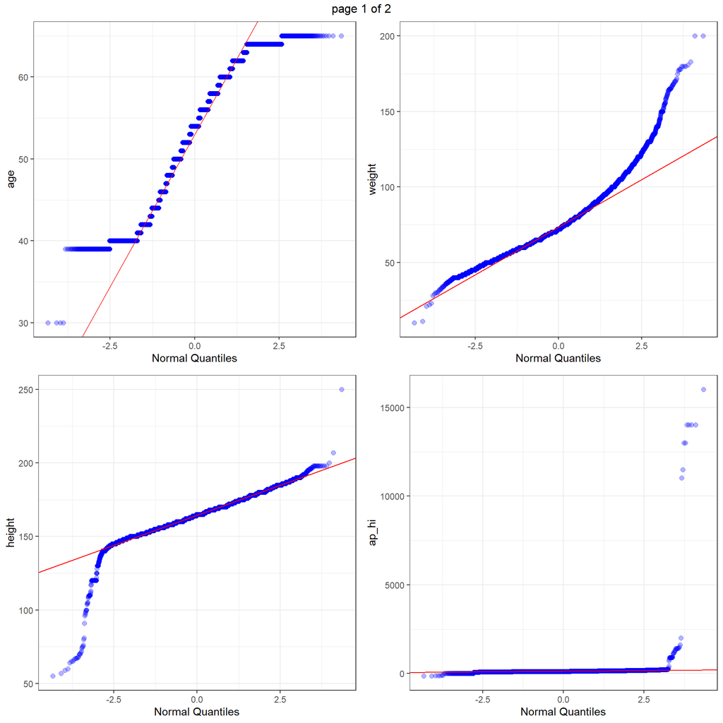

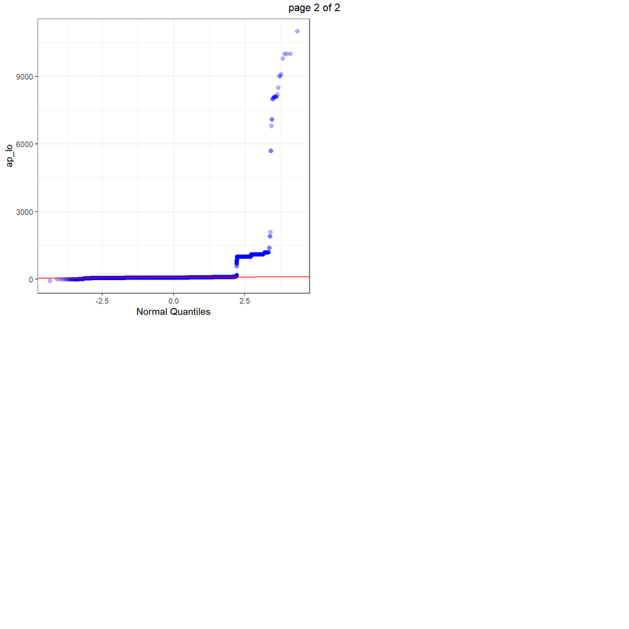

#### Density plots for Numerical variables - Univariate

Density plot for all Numerical variables

```
## $`0`
```

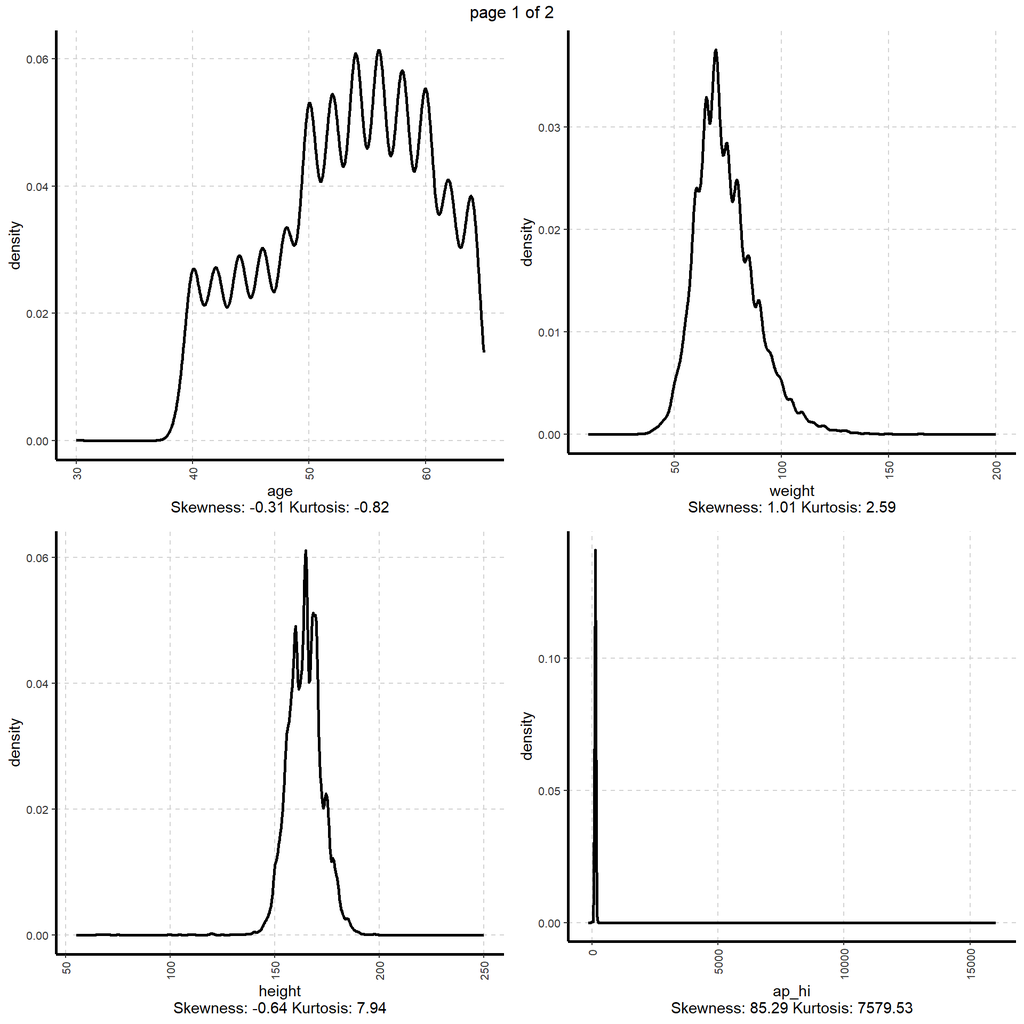

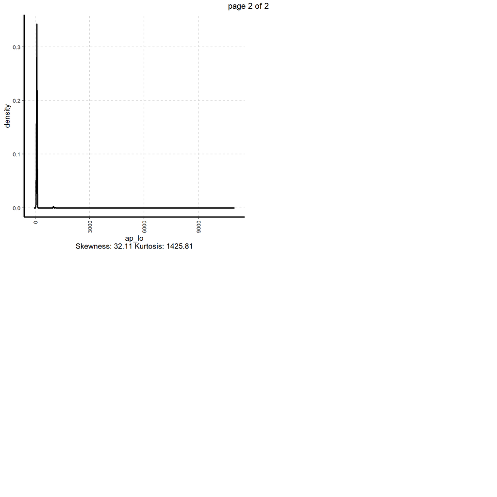

```r
ExpNumViz(data,target=NULL,type=1,Page=c(2,2),theme=theme,sample=sn)
```

#### Scatter plot for all numeric features - Bivariate analysis

```
## $`0`
```

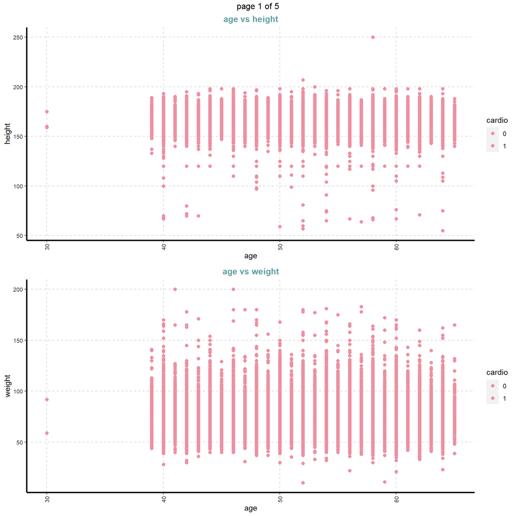

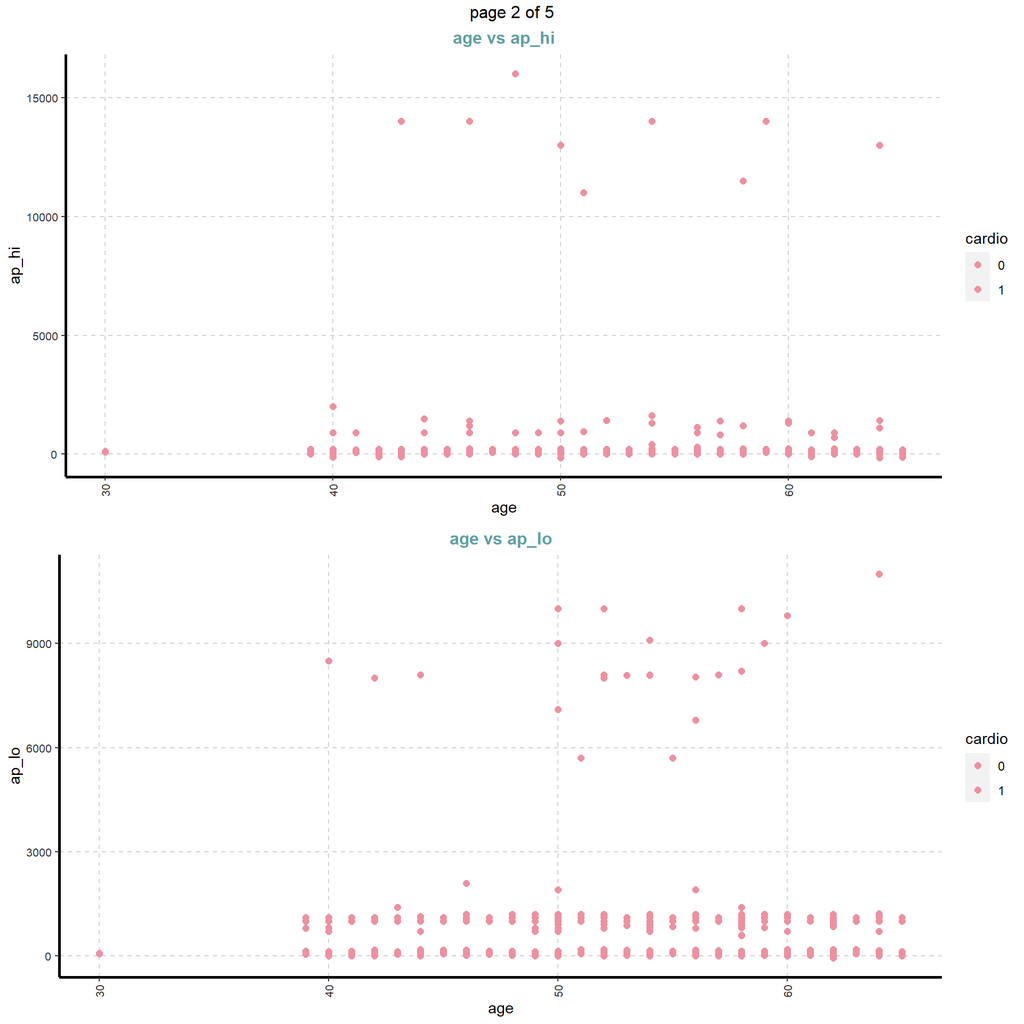

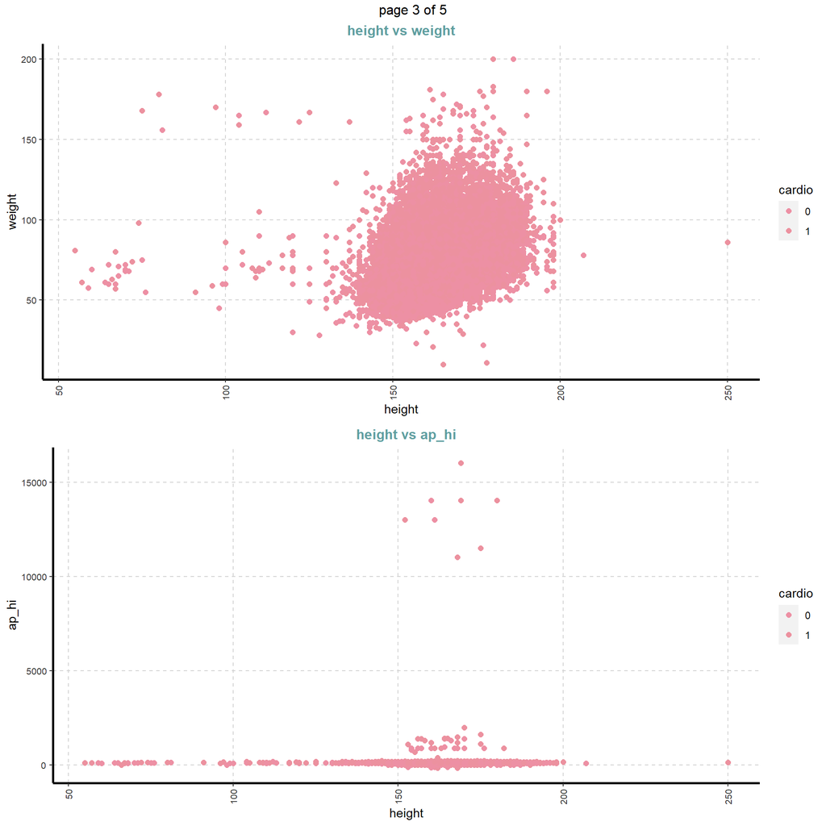

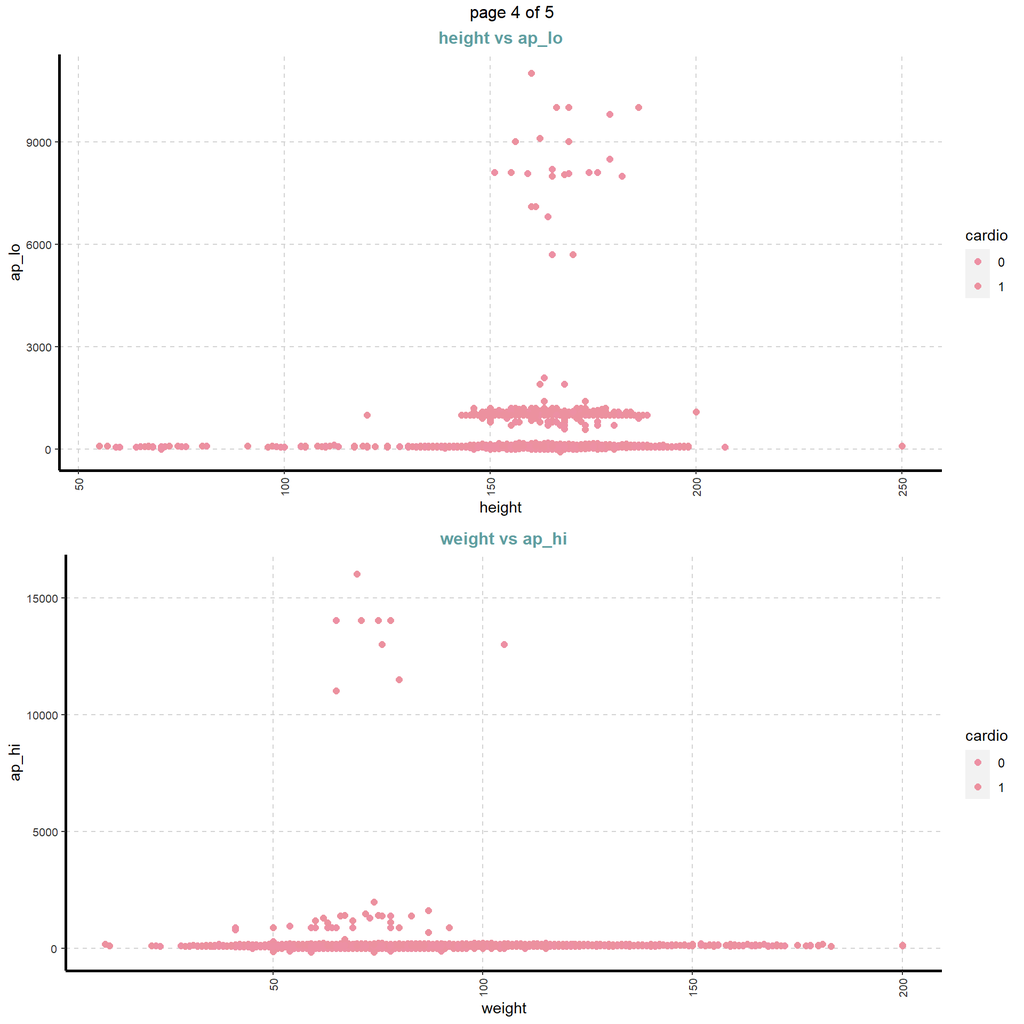

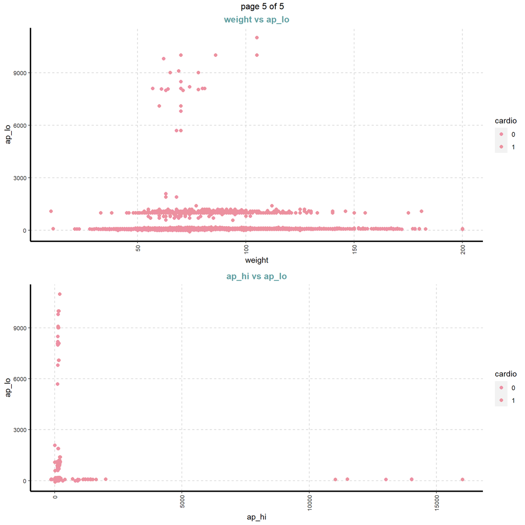

```r
ExpNumViz(data,target=Target,Page=c(2,1),theme=theme,sample=sn,scatter=TRUE)
```

#### Box plots for all numeric features vs categorical dependent variable - Bivariate comparision only with categories

Boxplot for all the numeric attributes by each category of **cardio**

```
## $`0`
```

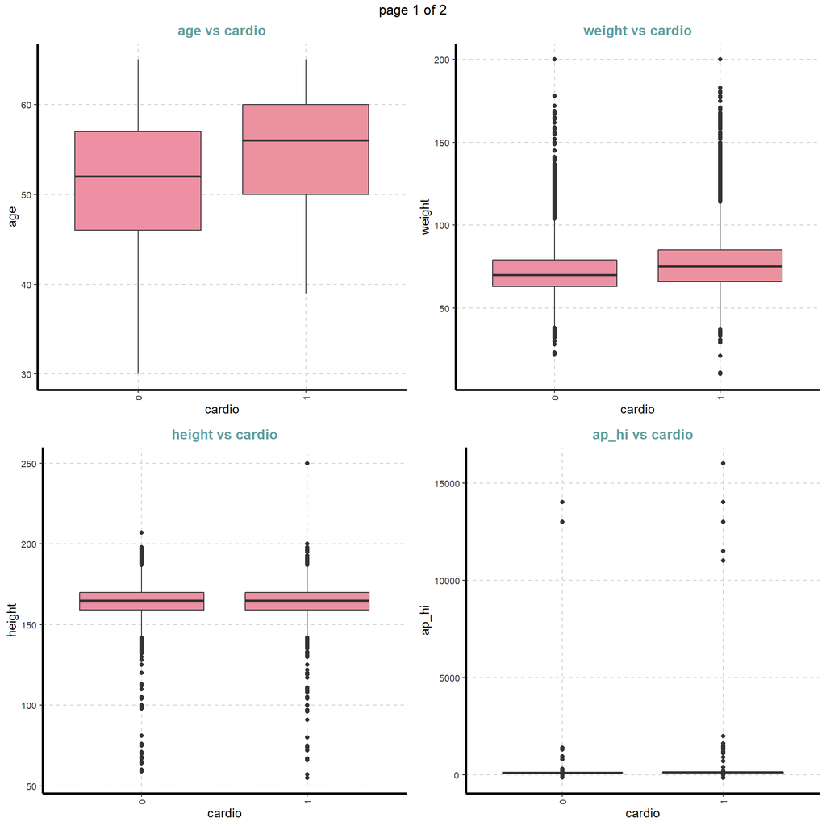

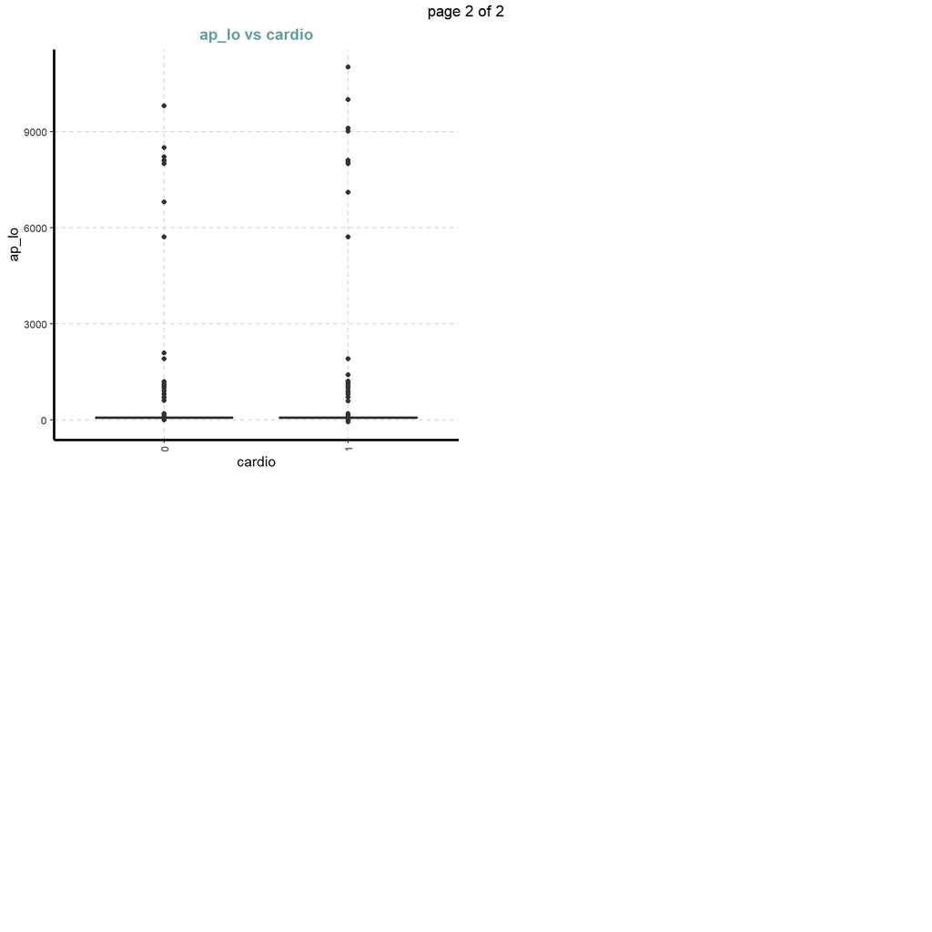

```r
ExpNumViz(data,target=Target,type=2,theme=theme,Page=c(2,2),sample=sn)
```

### 4. Summary of categorical variables

Summary of categorical variable

**Cross tabulation with target variable**

- Custom tables between all categorical independent variables and traget variable **cardio**

```r
ExpCTable(data,Target=Target,margin=1,clim=10,nlim=5,round=2,bin=NULL,per=F)
```

| VARIABLE | CATEGORY | cardio:0 | cardio:1 | TOTAL |
| --- | --- | --- | --- | --- |
| gender | 1 | 22914 | 22616 | 45530 |
| gender | 2 | 12107 | 12363 | 24470 |
| gender | TOTAL | 35021 | 34979 | 70000 |
| cholesterol | 1 | 29330 | 23055 | 52385 |
| cholesterol | 2 | 3799 | 5750 | 9549 |
| cholesterol | 3 | 1892 | 6174 | 8066 |
| cholesterol | TOTAL | 35021 | 34979 | 70000 |
| gluc | 1 | 30894 | 28585 | 59479 |
| gluc | 2 | 2112 | 3078 | 5190 |
| gluc | 3 | 2015 | 3316 | 5331 |

[output cut: 10 more lines]

**Information Value**

```r
ExpCatStat(data,Target=Target,Label=label,result = "IV",clim=10,nlim=5,Pclass=Rc)
```

| Variable | Class | Out_1 | Out_0 | TOTAL | Per_1 | Per_0 | Odds | WOE | IV | Ref_1 | Ref_0 | Target |
| --- | --- | --- | --- | --- | --- | --- | --- | --- | --- | --- | --- | --- |
| gender.1 | 2 | 12107 | 12363 | 24470 | 0.35 | 0.35 | 0.97 | 0.00 | 0.00 | 0 | 1 | cardio |
| gender.2 | 1 | 22914 | 22616 | 45530 | 0.65 | 0.65 | 1.03 | 0.00 | 0.00 | 0 | 1 | cardio |
| cholesterol.1 | 1 | 29330 | 23055 | 52385 | 0.84 | 0.66 | 2.67 | 0.24 | 0.04 | 0 | 1 | cardio |
| cholesterol.2 | 3 | 1892 | 6174 | 8066 | 0.05 | 0.18 | 0.27 | -1.27 | 0.17 | 0 | 1 | cardio |
| cholesterol.3 | 2 | 3799 | 5750 | 9549 | 0.11 | 0.16 | 0.62 | -0.37 | 0.02 | 0 | 1 | cardio |
| gluc.1 | 1 | 30894 | 28585 | 59479 | 0.88 | 0.82 | 1.67 | 0.07 | 0.00 | 0 | 1 | cardio |
| gluc.2 | 2 | 2112 | 3078 | 5190 | 0.06 | 0.09 | 0.67 | -0.40 | 0.01 | 0 | 1 | cardio |
| gluc.3 | 3 | 2015 | 3316 | 5331 | 0.06 | 0.09 | 0.58 | -0.40 | 0.01 | 0 | 1 | cardio |
| smoke.1 | 0 | 31781 | 32050 | 63831 | 0.91 | 0.92 | 0.90 | -0.01 | 0.00 | 0 | 1 | cardio |
| smoke.2 | 1 | 3240 | 2929 | 6169 | 0.09 | 0.08 | 1.12 | 0.11 | 0.00 | 0 | 1 | cardio |

[output cut: 46 more lines]

**Statistical test**

```r
ExpCatStat(data,Target=Target,Label=label,result = "Stat",clim=10,nlim=5,Pclass=Rc)
```

| Variable | Target | Unique | Chi-squared | p-value | df | IV Value | Cramers V | Degree of Association | Predictive Power |
| --- | --- | --- | --- | --- | --- | --- | --- | --- | --- |
| gender | cardio | 2 | 4.570 | 0.033 | 1 | 0.00 | 0.01 | Very Weak | Not Predictive |
| cholesterol | cardio | 3 | 3423.439 | 0.000 | 2 | 0.23 | 0.22 | Moderate | Medium Predictive |
| gluc | cardio | 3 | 586.912 | 0.000 | 2 | 0.02 | 0.09 | Weak | Not Predictive |
| smoke | cardio | 2 | 16.678 | 0.000 | 1 | 0.00 | 0.02 | Very Weak | Not Predictive |
| alco | cardio | 2 | 3.697 | 0.055 | 1 | 0.00 | 0.01 | Very Weak | Not Predictive |
| active | cardio | 2 | 88.801 | 0.000 | 1 | 0.00 | 0.04 | Very Weak | Not Predictive |
| age | cardio | 10 | 4017.254 | 0.000 | 9 | 0.23 | 0.24 | Moderate | Medium Predictive |
| height | cardio | 10 | 44.395 | 0.000 | 9 | 0.00 | 0.03 | Very Weak | Not Predictive |
| weight | cardio | 10 | 2349.729 | 0.000 | 9 | 0.13 | 0.18 | Weak | Somewhat Predictive |
| ap_hi | cardio | 6 | 15051.773 | 0.000 | 5 | 1.04 | 0.46 | Strong | Highly Predictive |

[output cut: 1 more lines]

**Variable importance based on Information value**

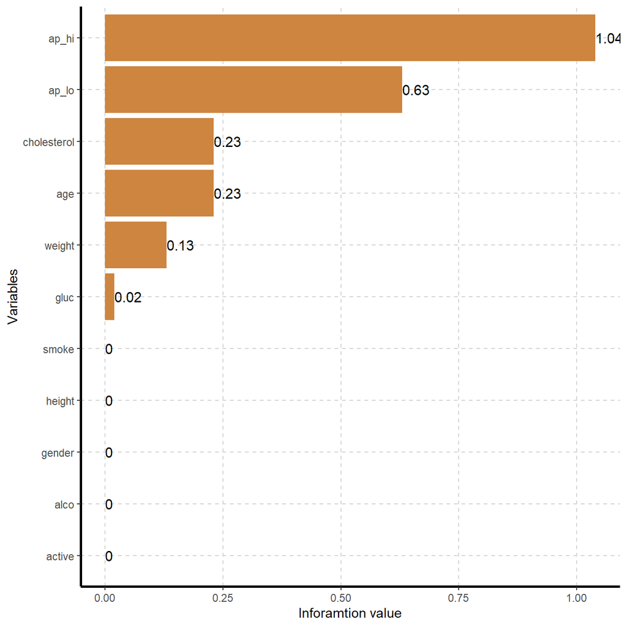

```r
varimp <- ExpCatStat(data,Target=Target,result = "Stat",clim=10,nlim=5,Pclass=Rc,bins=10,plot=TRUE,top=30,Round=2)
```

### 5. Distributions of categorical variables

Graphical representation of all categorical variables

- Bar plot (Univariate)
- Stacked Bar plot (Bivariate)

**Bar plots for all categorical variables**

- Bar plot with vertical or horizontal bars for all categorical variables

```
## $`0`
```

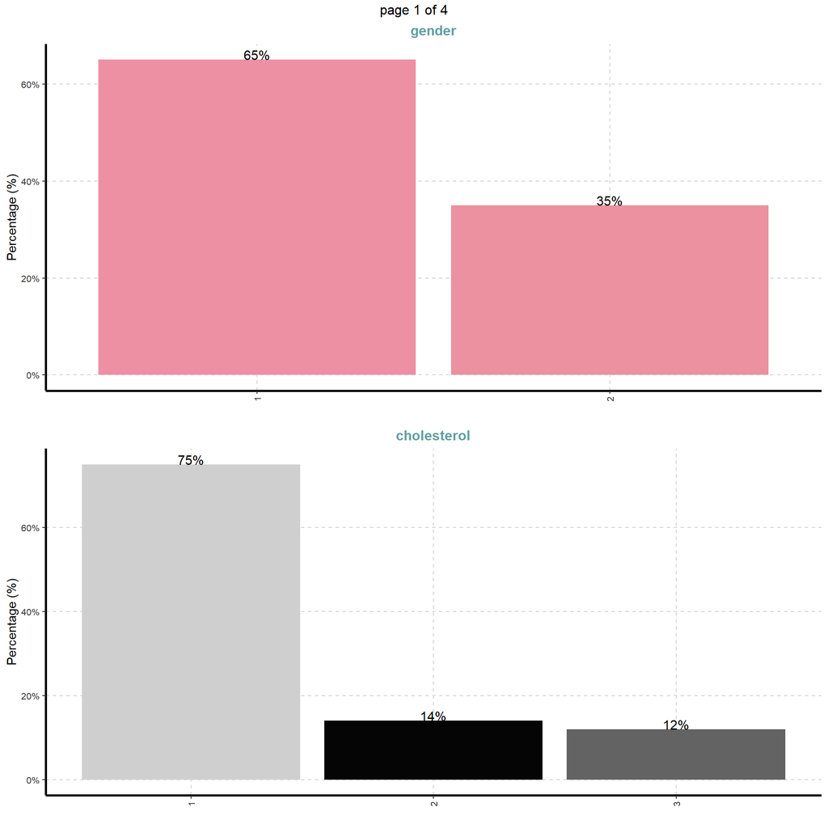

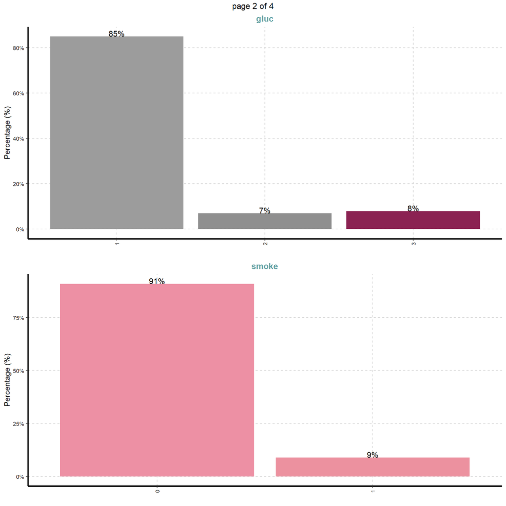

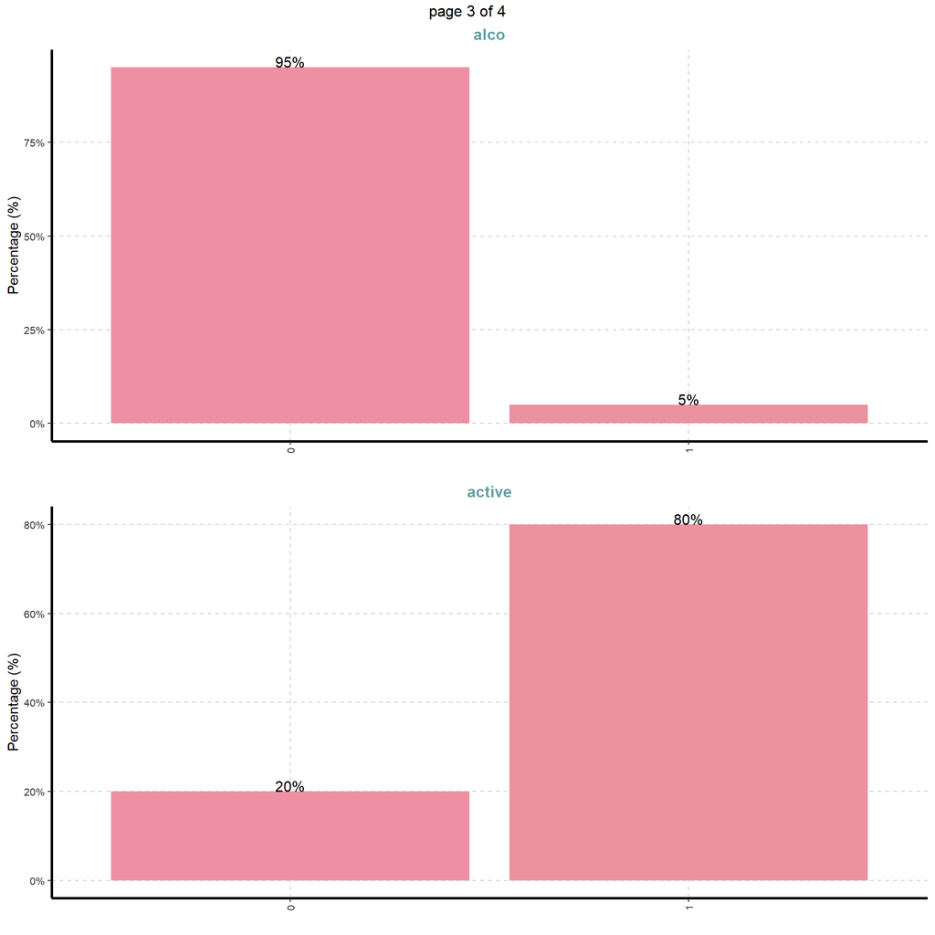

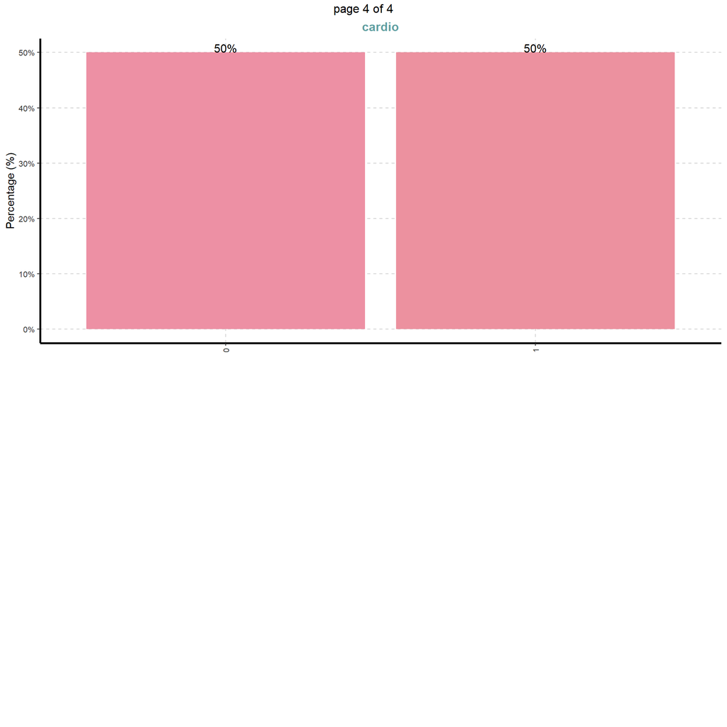

```r
ExpCatViz(data,target=NULL,fname=NULL,clim=10,margin=2,theme=theme,Page = c(2,1),sample=sc)
```

- Stacked bar plot with vertical or horizontal bars for all categorical variables

```
## $`0`
```

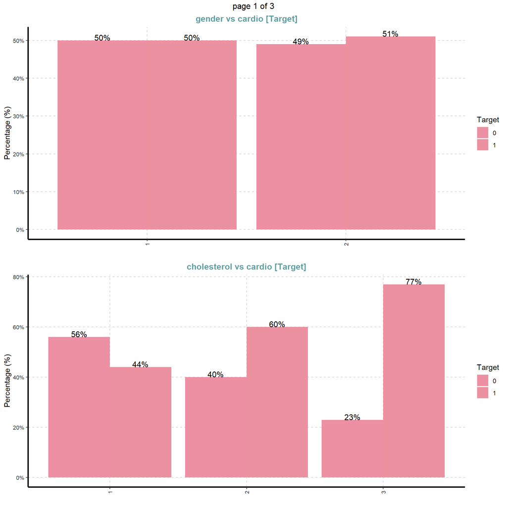

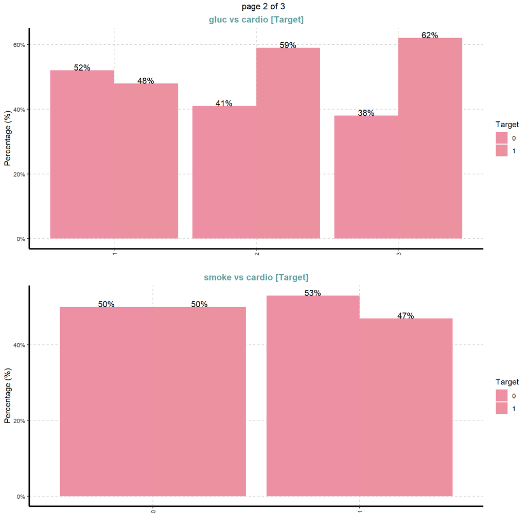

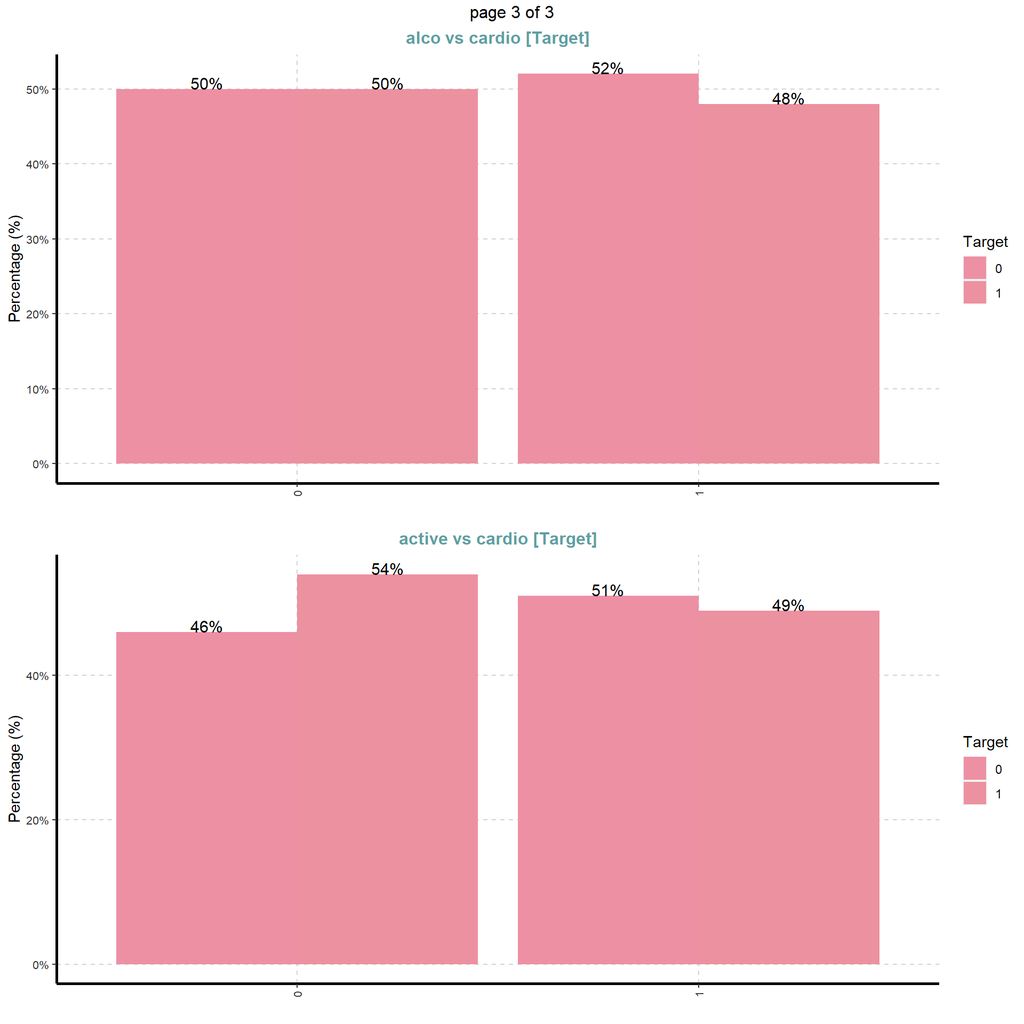

```r
ExpCatViz(data,target=Target,fname=NULL,clim=10,margin=2,theme=theme,Page = c(2,1),sample=sc)
```